# COVID-19 Pandemic in Kuwait

G.A.A.S.T.Perera

#### AS2018478

[figure not shown]

### **1. Introduction**

The COVID-19 pandemic is an ongoing global pandemic of corona virus disease 2019 (COVID-19) caused by severe acute respiratory syndrome corona virus 2 (SARS-CoV-2).The novel virus was first identified in Wuhan, China, in December 2019. The disease transmits when people breathe in air contaminated by droplets and small airborne particles.More than 232,611,641 people in all over the world have been infected with the corona virus, at least 4,762,160 have died and over 209,246,990 recovered cases are reported so far.In this report, the Kuwait COVID-19 case will be analyzed and compared with few other neighboring countries.

#### **Visualization of the location on World Map**

Kuwait is a tiny country nestling at the top of the Gulf. Flanked by powerful neighbors Saudi Arabia, Iraq and Iran, its strategic location and massive oil reserves make it one of the world’s richest countries per capital.Kuwait has a coastal length of approximately 500 km. The Population of the Kuwait is 4 million. The native and official language in Kuwait is Arabic and English is the second language taught in public schools.Major religion of the country is Islam.

[figure not shown]

#### **Climate Condition**

In Kuwait, there’s a subtropical desert climate, with mild winters and very hot summers. The sun usually shines all year round. Rainfall, slightly higher than 100 millimeters (4 inches) per year, occurs mainly from November to April. If there is enough rainfall, the desert turns green from mid-March to the end of April.The frequent winds from the northwest are cool in winter and spring and hot in summer.

Winter, from December to February, is mild: the daily average temperature in January is 13.5 degrees Celsius (56 °F).In winter, the sun often shines, but some cloudy days also possible, maybe with some rain.In spring, the prevailing weather is sunny; the temperature rises rapidly, and already in April, highs are around 33 °C (92 °F). The wind from the Arabian desert can raise the temperature and bring sandstorms.Summer in Kuwait is very hot and windy; the prevailing wind blows from the interior, and therefore the influence of the sea is minimal. From June to August, the temperature is normally around 45/46 °C (112/115 °F) during the day and around 29/30 °C (84/87 °F) at night.In autumn, the weather is still hot and sunny in October, while the temperature drops below 30 °C (86 °F) during the month of November.

#### **Lockdown status of the country and Actions taken by the government**

The first confirmed Covid-19 case in Kuwait was announced on 24 February 2020. After that Kuwait Government announced the first full curfew in the country and it was ended on 30 May 2020 and started taking steps towards a gradual return to normal life by placing a partial curfew from 6 pm until 6 am. Initially, the country started with a voluntary stay at home approach since midnight of 11 March on the assessment by the Ministry of Health , with the government suspending work across all government sectors except emergency services. All commercial air travel and border travel were suspended since midnight of 14 March 2020.Partial curfew was implemented since 22 March 2020 where curfew hours were between 5 pm until 4 am and this was amended on 6 April, where end of curfew hours were extended from 4 am to 6 am.With the start of the holy month of Ramadan on 24 April 2020, the partial curfew was further amended to 4 pm until 8 am with special permissions for deliveries from 5 pm until 1 am . On 10 May, the country was placed under full curfew based on the assessment of the Ministry of Health, until 31 May 2020.Then again, a curfew of one month was imposed from 5 p.m. until 5 a.m. starting 7 March 2021 until 8 April 2021, after 1,716 new corona virus cases were recorded on 4 March 2021.

The government estimated the extra costs to equip the health care system with the necessary medical supplies at KWD 500 million.The Minister of Health designated Jabber Al Ahmad Hospital, with a clinical capacity of 1.130 beds, as the main hospital for corona virus cases. Expecting demands for masks and ventilators, the government bought 12 million masks for the month of January 2020 alone and it increased the number of ventilators in hospitals It also bought tens of thousands of testing kits and medical supplies in order to create a strategic stock.9 In addition, the government supported the Kuwait Foundation for the Advancement of Science in this crisis, which in turn imported more than 170 ventilators and personal protective devices from China as part of the foundation’s efforts in the Emergency Response Program for the Covid-19 crisis.The government commissioned the Ministry of Interior to establish mechanisms for the implementation of the curfew and asked the National Guard to assist the police during the implementation process. Furthermore, the government closed all showrooms, shops and central markets and encouraged online sale. It also imposed penalties of up to three years of imprisonment and a fine of KWD 10.000 for curfew violators Under the guidance of His Highness Sheikh Sabah al-Ahmad al-Sabah, the government also announced an economic reform package to maintain the good living standards of the Kuwaitis and to support businesses. The package included “postponing the payment of social insurance to the workers in the private and oil companies, as well as for the owners of small and medium enterprises for six months.”12 Instructed by the government, the Federation of Kuwaiti Banks also suspended the repayment of loans and debts to citizens for six months.

Finally, the government ensured that the supplies of food and medicines to citizens and residents will continue with affordable prices. The Ministry of Trade and Industry also stabilized the prices in order to prevent companies from taking advantage of the citizens’ needs. During the crisis, the government was very transparent. It posted all information it possessed on Covid-19 as well as of its measures on the government communication platform, an official media website that gives the latest laws, facts, and statistics related to Covid-19.13 This information is also available on the media platform of the Ministry of Health, which gives information about the number of the new cases, recovered ones, and the latest developments of the pandemic.The Kuwaitis are already adapting their lives to deal with the era of social distancing: online shopping became preferable by most people, social gathering and professional meetings are taking place in the virtual space, and the government is providing its services through the portal of e-government.

### **2. Exploratory Data Analysis**

First we look at the summary of the corona virus cases in Kuwait (The data was collected from 2020-01-22 to 2021-09-18.)

```
##       date              province           country               lat
##  Min.   :2020-01-22   Length:1818        Length:1818        Min.   :29.31
##  1st Qu.:2020-06-21   Class :character   Class :character   1st Qu.:29.31
##  Median :2020-11-19   Mode  :character   Mode  :character   Median :29.31
##  Mean   :2020-11-19                                         Mean   :29.31
##  3rd Qu.:2021-04-20                                         3rd Qu.:29.31
##  Max.   :2021-09-18                                         Max.   :29.31
##       long           type               cases
##  Min.   :47.48   Length:1818        Min.   :   0.0
##  1st Qu.:47.48   Class :character   1st Qu.:   4.0
##  Median :47.48   Mode  :character   Median : 271.5
##  Mean   :47.48                      Mean   : 467.3
##  3rd Qu.:47.48                      3rd Qu.: 810.8
##  Max.   :47.48                      Max.   :1993.0
```

#### *Analysis of Death, Confirmed, Recovered and Active Cases in Kuwait*

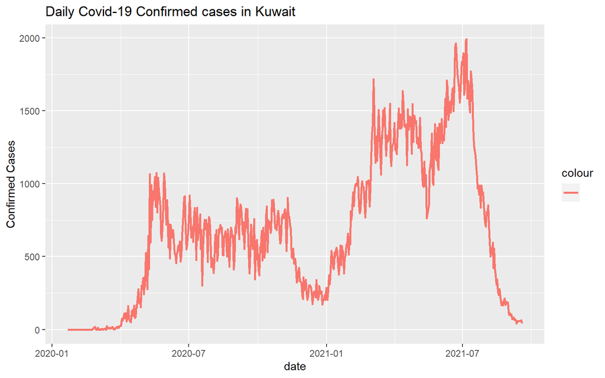

Above graph shows the confirmed number of corona patients in Kuwait in daily basis. According to that number of confirmed Corona patients have been increased since begin of 2021 and the end half of 2021 confirmed number of Corona patients have been decreased.This shows the Kuwait government is having the situation under control for now.

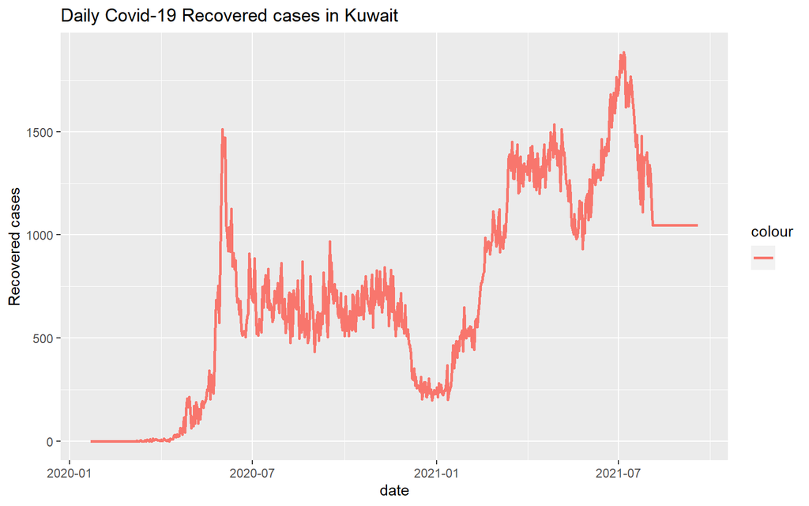

Above graph shows the number of patients recovered from corona in Kuwait in daily basis.Number of patients recovered in a day has also increased from begin of 2021 and again in the end half of 2021 number of patients recovered in a day has decreased.

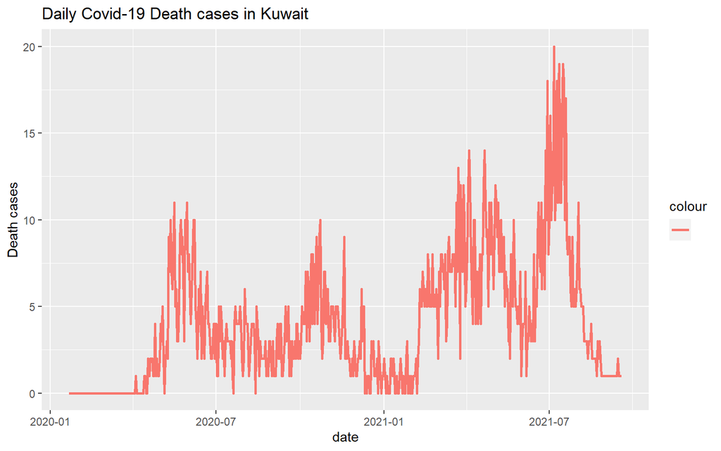

Above graph shows the number of death from Corona in Kuwait in daily basis.In the end half 2021, number of death from Corona has been reached to the peak.

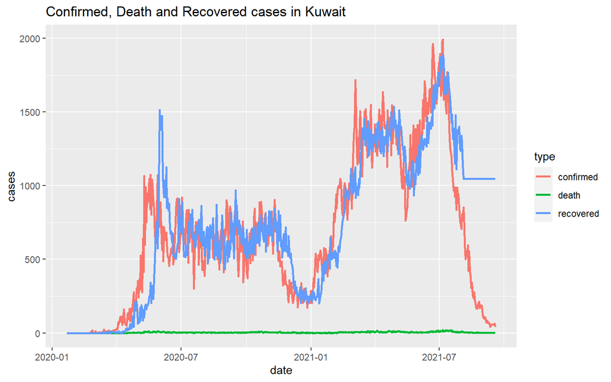

[output not shown]

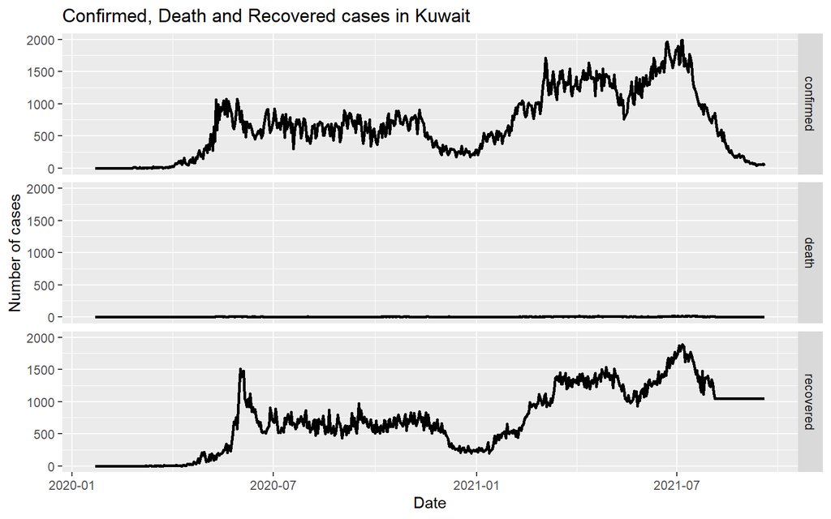

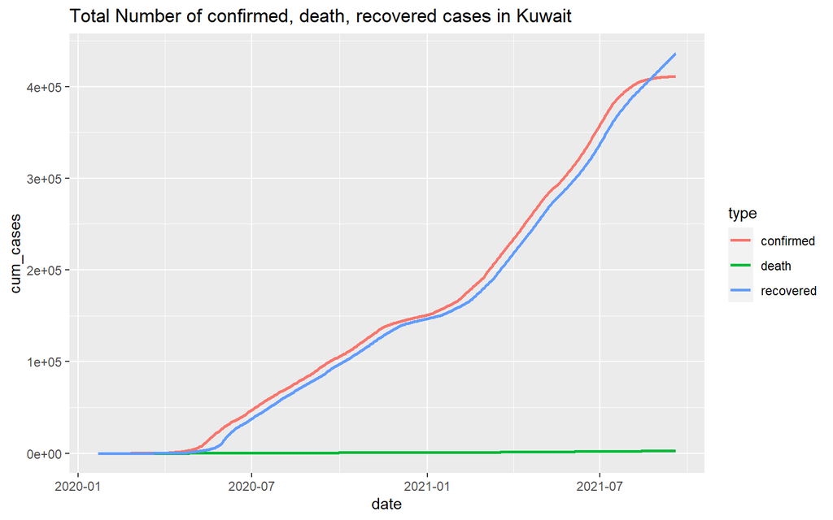

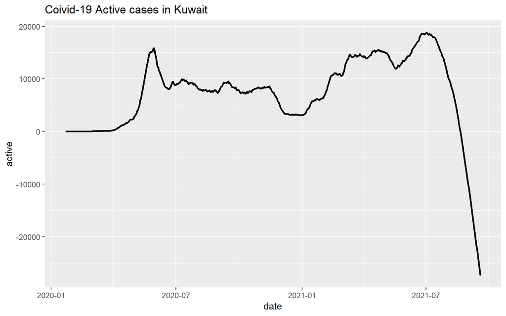

For this graph the number of active cases is calculated by excluding from cumulative values of confirmed cases the number of cumulative values of recoveries and deaths.

#### *Comparison with other Countries*

United Arab Emirates (UAE) ,Iran, Qatar and Iraq have been selected to compare the COVID 19 pandemic in Kuwait, because all these are neighboring countries

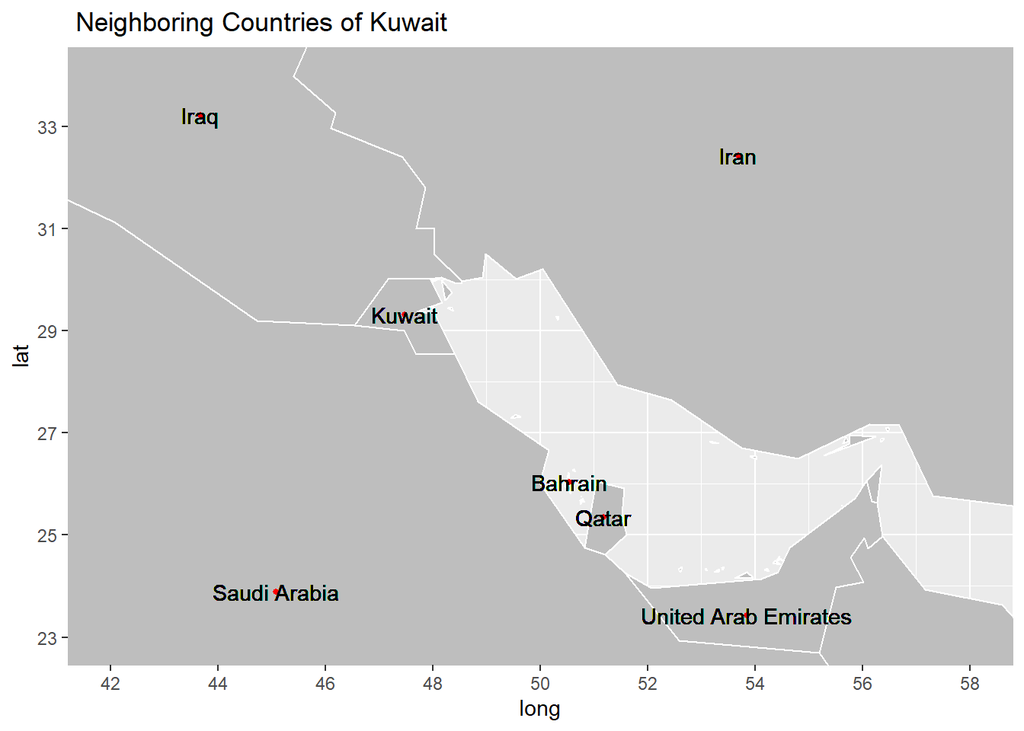

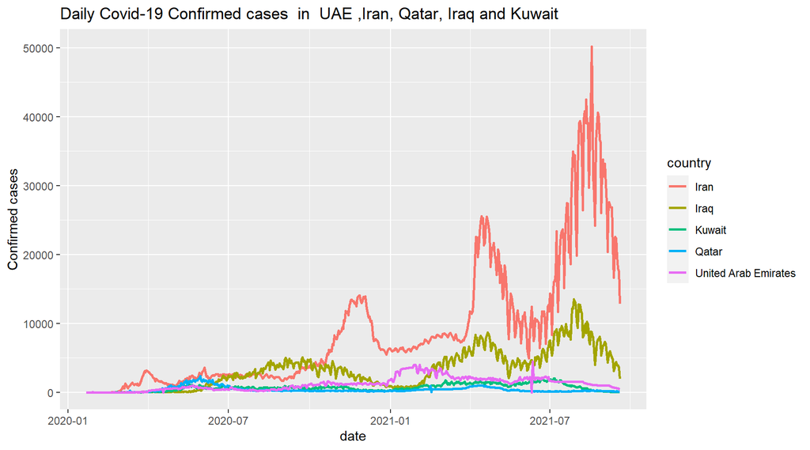

Above graph shows that daily confirmed cases in Kuwait and Qatar are very low compared to other countries in the same continent. Also, Iran has the high number of daily confirmed corona patients among other countries.

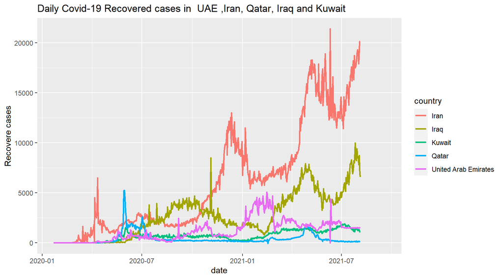

Above graph shows that daily recovered cases in Iran was larger than other four countries

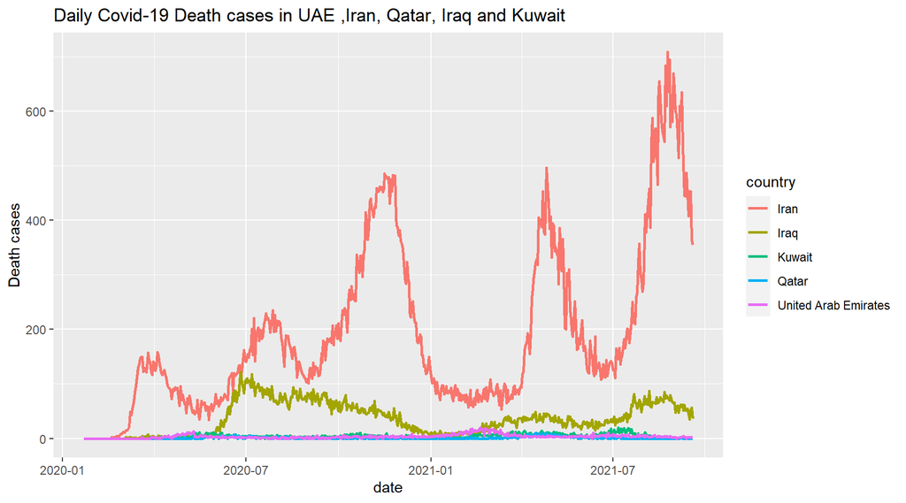

It can be seen that Iran has a higher proportion of daily death cases that resulted in deaths when compared with other four countries. UAE, Kuwait and Qatar have very low proportion of daily deaths with compare to the Iran.

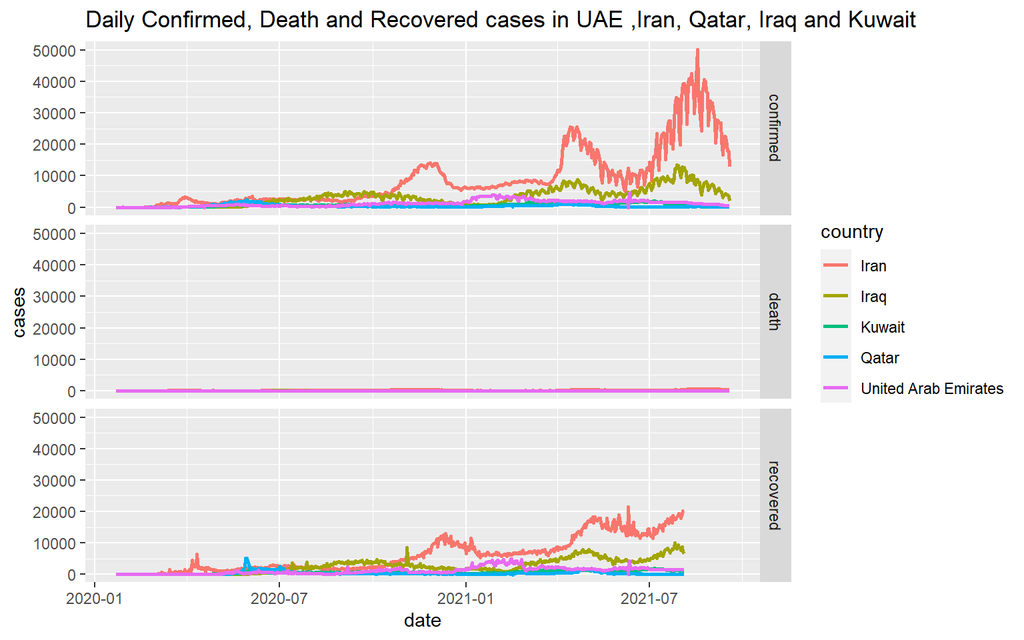

Above graph shows that daily confirmed, death and recovered cases in Kuwait and Qatar negligible when compared to other countries in the same continent.Both number of confirmed cases and recovered cases are higher in Iran.

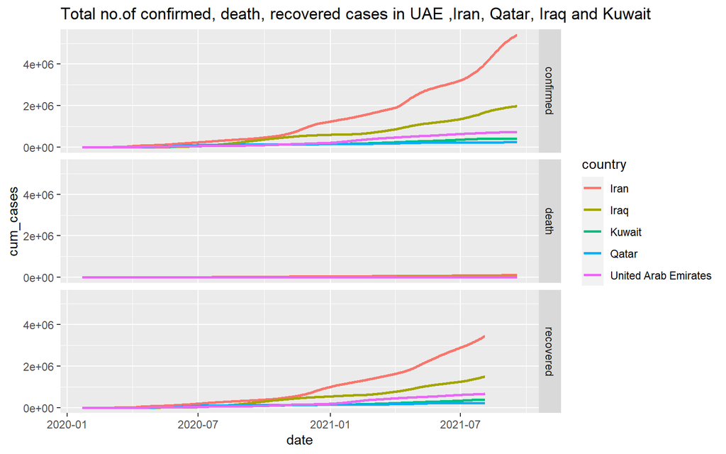

This graph also confirms that total number of confirmed, death and recovered cases in Kuwait and Qatar negligible when compared to other countries in the same continent.Also the number of confirmed cases and recovered cases are higher in Iran.

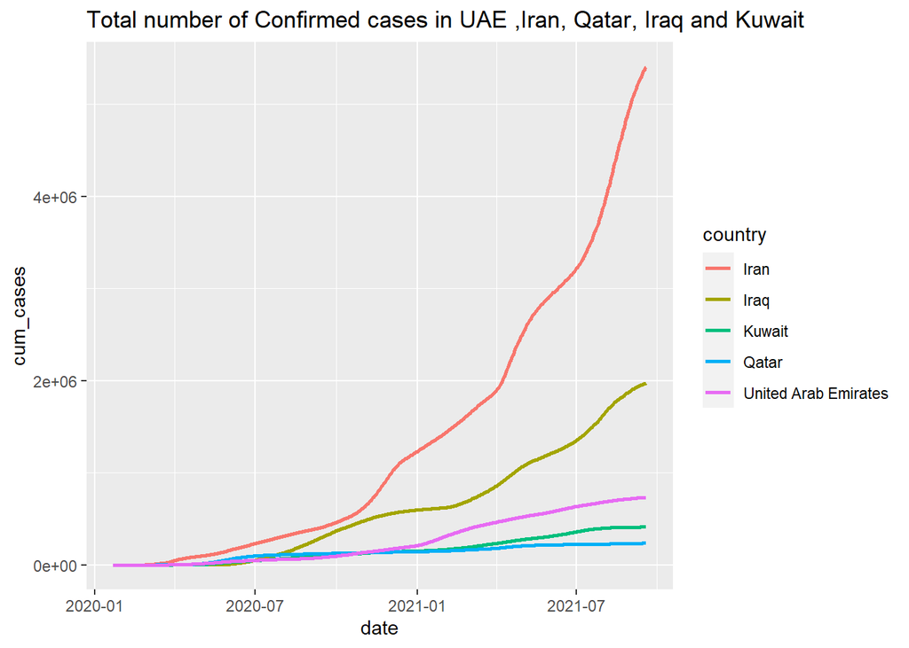

Above plot shows that total number of confirmed cases in UAE is lower than Iran and Iraq but higher than Kuwait and Qatar.

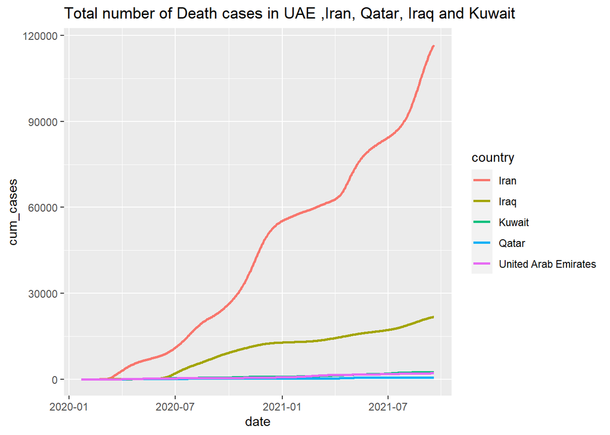

Above plot shows that total number of death cases in UAE are less than Iran and Iraq but almost equal to the Qatar and Kuwait.

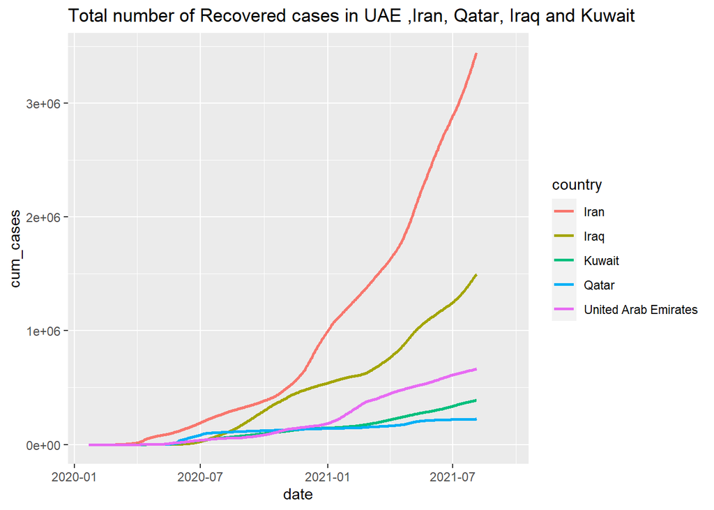

### **4. References**

1. https://www.worldometers.info/coronavirus/
2. https://en.wikipedia.org/wiki/COVID-19_pandemic
3. https://www.bbc.com/news/world-middle-east-14644252
4. https://www.britannica.com/place/Kuwait/Climate
5. https://en.wikipedia.org/wiki/COVID-19_pandemic_in_Kuwait#Action_taken_on_the_deceased
6. https://www.kas.de/documents/286298/8668222/Policy+Report+No+7+Kuwait+during+COVID+19.pdf/40823658-bedc-17ab-b2df-ee24ff82bc50?version=1.0&t=1592400225219